````yaml
---
title: "R Markdown Final Project"
author: "Rajdai Bhikam"
date: "2025-04-30"
output: html_document
---


##This assignment outlines the core functions I created for my final project using the `mtcars` dataset. These functions are part of my R package `RBhikam`, designed to help new R users clean, summarize, and visualize data easily.

---
**FUNCTION 1**

**Purpose:**
This function is used to remove missing values and convert column names to lowercase.

**Input:**
`df`(data frame): The dataset to clean

**Output:**
A clean dataframe with no `NA` values and standardize column names.

**Code:**


``` r
clean_data <- function(df) {
  df <- na.omit(df)
  names(df) <- tolower(names(df))
  return(df)
}
````

**Example:**

```r
cleaned <- clean_data(mtcars)

head(cleaned)
```

```
##                    mpg cyl disp  hp drat    wt  qsec vs am gear carb
## Mazda RX4         21.0   6  160 110 3.90 2.620 16.46  0  1    4    4
## Mazda RX4 Wag     21.0   6  160 110 3.90 2.875 17.02  0  1    4    4
## Datsun 710        22.8   4  108  93 3.85 2.320 18.61  1  1    4    1
## Hornet 4 Drive    21.4   6  258 110 3.08 3.215 19.44  1  0    3    1
## Hornet Sportabout 18.7   8  360 175 3.15 3.440 17.02  0  0    3    2
## Valiant           18.1   6  225 105 2.76 3.460 20.22  1  0    3    1
```

**FUNCTION 2** **Purpose:** This function groups data by categorical variables and then calculates the mean of a selected column **Input:** `df`: The dataframe `group_col`: column by group `summary_col`: summary of numeric column

**Output:** A summary of the datframe

**CODE:**

```r
summarize_by_group <- function(df, group_col, summary_col) {
  df |>
    dplyr::group_by(.data[[group_col]]) |>
    dplyr::summarise(mean_value = mean(.data[[summary_col]], na.rm = TRUE))
}
```

**Example:**

```r
summarize_by_group(mtcars, "cyl", "mpg")
```

```
## # A tibble: 3 × 2
##     cyl mean_value
##   <dbl>      <dbl>
## 1     4       26.7
## 2     6       19.7
## 3     8       15.1
```

**FUNCTION 3**

**Purpose:** This function creates a bar plot of the grouped data.

**Input:** `df`: The dataframe with grouped summaries `x`: column name for x-axis `y`: column name for y-axis

**Output:** A ggplot2 chart

**CODE:**

```r
library(ggplot2)
plot_summary <- function(df, x, y) {
  ggplot(data = df, aes(x = .data[[x]], y = .data[[y]])) +
    geom_bar(stat = "identity", fill = "steelblue") +
    theme_minimal()
}
```

**Example:**

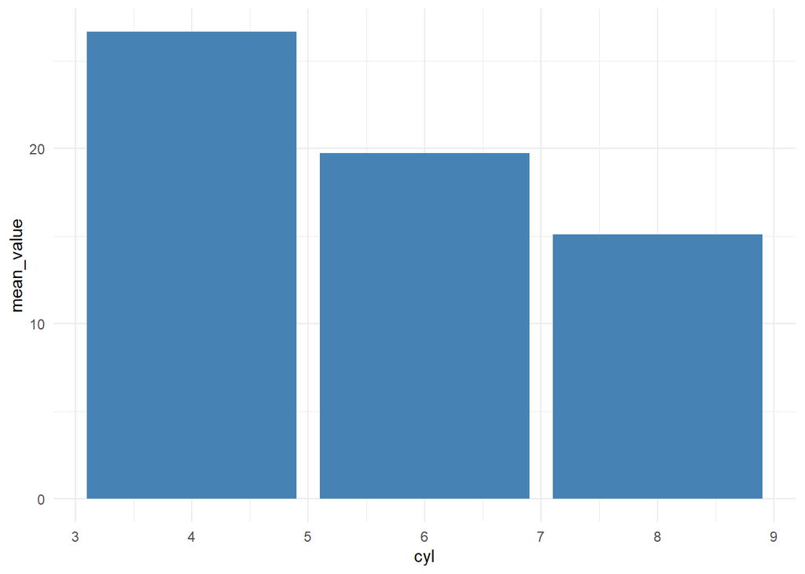

```r
summary_df <- summarize_by_group(mtcars, "cyl", "mpg")
plot_summary(summary_df, "cyl", "mean_value")
```

**Package Structure**

The RBhikam package contains the following components

- `DESCRIPTION` with metadata and dependencies
- `R/` folder with individual `.R` function files
- `data/mtcars.rda` for the sample dataset
- `README.md` for GitHub overview
- `man/` folder with auto-generated documentation
- `tests/` folder (optional, to test functions)

**Installation Instructions**

The package was installed and tested using:

```r
devtools::document()
devtools::install()
library(RBhikam)
```

**Reflections & Challenges**

- **What worked:** Function creation and documentation using `roxygen2` was straightforward after the first attempt.
- **What I learned:** I learned how R packages are structured, documented, tested, and published on GitHub.
- **Challenges:** My biggest challenge was fixing documentation errors and making sure functions exported properly. I had a hard time getting everything to work because of the multiple errors.
- **AI Disclosure:** I used ChatGPT to help debug errors, and clarify package structure.All code was written, tested, and verified manually by me, and I used AI tools as a guide, not as a substitute for learning. The final implementation reflects my own understanding and work.